# Lab6_Template

### Setup

```r
# Load packages needed
library(tidyverse)
library(openintro)
```

```r
# Create condensed dataframe loans
glimpse(loans_full_schema)
```

```
## Rows: 10,000
## Columns: 55
## $ emp_title                        <chr> "global config engineer ", "warehouse…
## $ emp_length                       <dbl> 3, 10, 3, 1, 10, NA, 10, 10, 10, 3, 1…
## $ state                            <fct> NJ, HI, WI, PA, CA, KY, MI, AZ, NV, I…
## $ homeownership                    <fct> MORTGAGE, RENT, RENT, RENT, RENT, OWN…
## $ annual_income                    <dbl> 90000, 40000, 40000, 30000, 35000, 34…
## $ verified_income                  <fct> Verified, Not Verified, Source Verifi…
## $ debt_to_income                   <dbl> 18.01, 5.04, 21.15, 10.16, 57.96, 6.4…
## $ annual_income_joint              <dbl> NA, NA, NA, NA, 57000, NA, 155000, NA…
## $ verification_income_joint        <fct> , , , , Verified, , Not Verified, , ,…
## $ debt_to_income_joint             <dbl> NA, NA, NA, NA, 37.66, NA, 13.12, NA,…
## $ delinq_2y                        <int> 0, 0, 0, 0, 0, 1, 0, 1, 1, 0, 0, 0, 0…
## $ months_since_last_delinq         <int> 38, NA, 28, NA, NA, 3, NA, 19, 18, NA…
## $ earliest_credit_line             <dbl> 2001, 1996, 2006, 2007, 2008, 1990, 2…
```

[output cut: 42 more lines]

```r
loans <- loans_full_schema %>%
  select(loan_amount, interest_rate, term, grade,
         state, annual_income, homeownership, debt_to_income)
```

#### Using the `loans` dataframe create a histogram for `interest_rate`. The histogram should have an appropriate amount of bins. Be sure to provide an apprppriate title and axis labels.

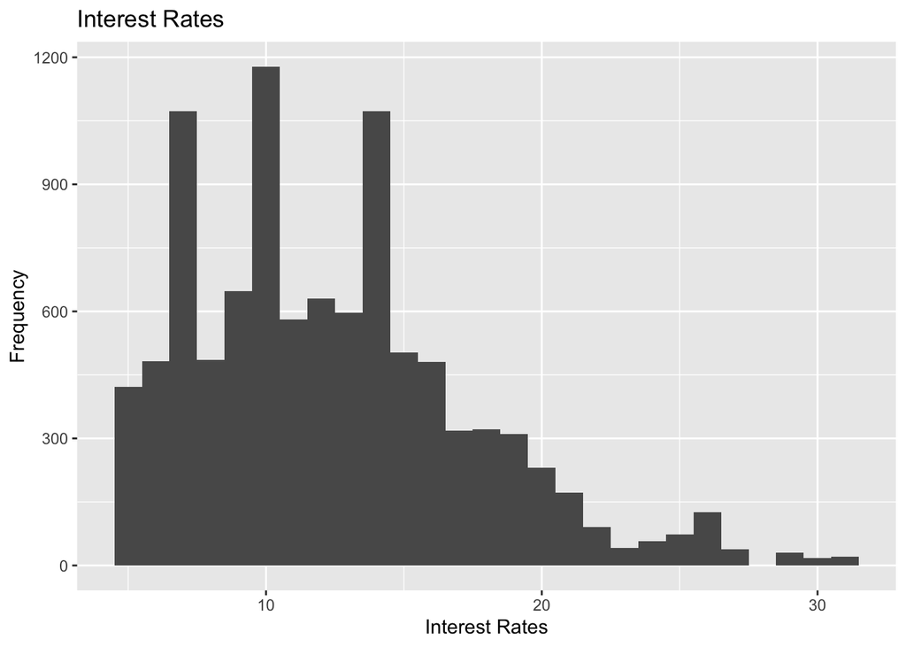

```r
ggplot(loans, aes(x = interest_rate)) +
  geom_histogram(binwidth = 1) +
  labs(
    x = "Interest Rates",
    y = "Frequency",
    title = "Interest Rates"
  )
```

#### Describe the shape of the distribution of `interest_rate`.

The graph looks right skewed.

#### Using the `loans` dataframe, create a facet histogram of `interest_rate` broken down by `grade`.

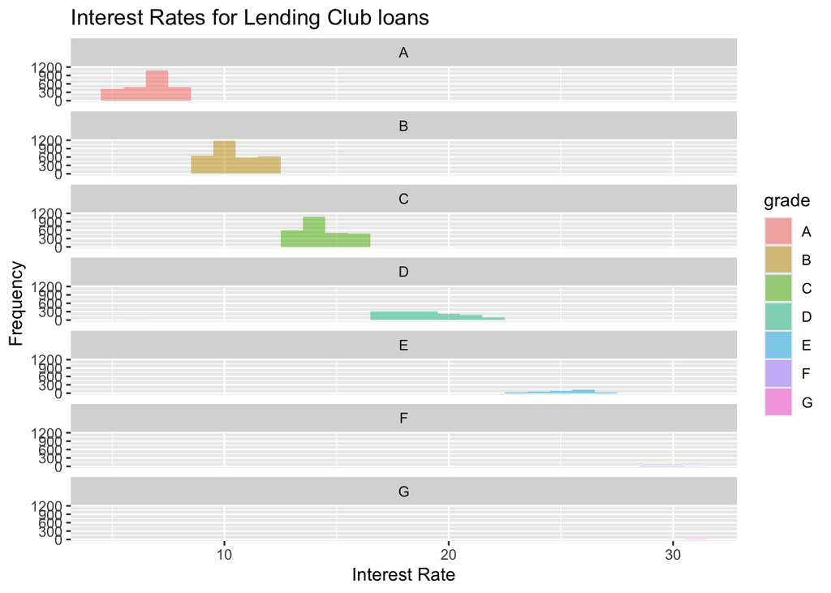

```r
ggplot(loans, aes(x = interest_rate, fill = grade)) +
  geom_histogram(binwidth = 1, alpha=0.5 ) +
  labs(
    x = "Interest Rate",
    y = "Frequency",
    title = "Interest Rates for Lending Club loans") +
   facet_wrap(~ grade, nrow=7)
```

#### Using the `loans` dataframe, create a density plot of `interest_rate` separated by `grade`. Use an appropriate adjustment value. Use appropriate titles and labels.

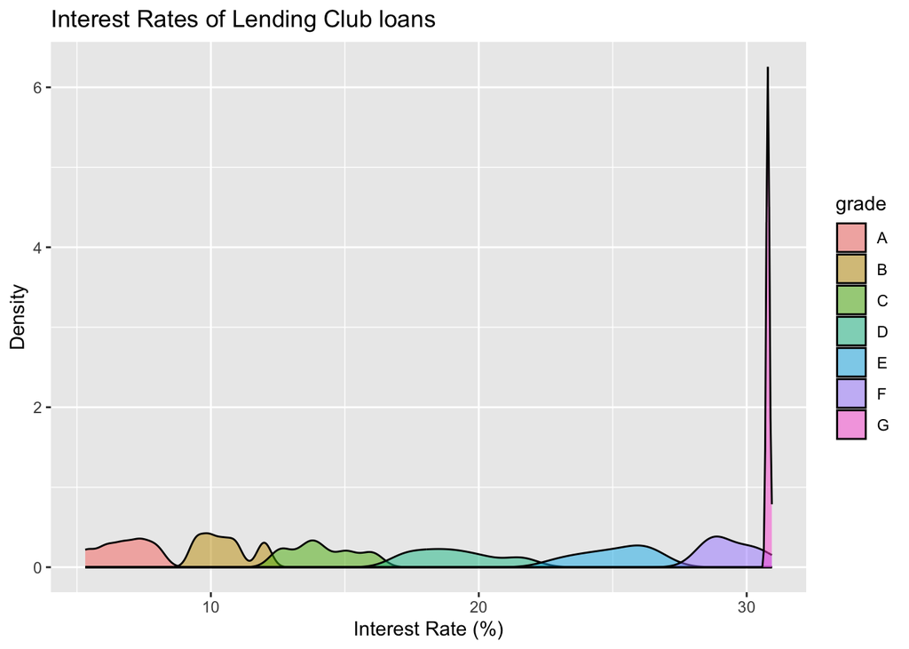

```r
ggplot(loans, aes(x = interest_rate,
                  fill = grade)) +
  geom_density(adjust = 2,
               alpha = 0.5) +
  labs(
    x = "Interest Rate (%)",
    y = "Density",
    title = "Interest Rates of Lending Club loans",
    fill = "grade"
  )
```

#### Do you notice anything unusual about this graph? Explain.

We can observe that the grades are related to interest rates of the load. And loans with G grade are very dense (interest rate > 30%). Rest of all graded loan rates are distributed normally.

#### Using the loans dataframe, create boxplots of `interest_rate` sepearted by `grade`, coloring each box a different color based on `grade`. Use appropriate labels and titles.

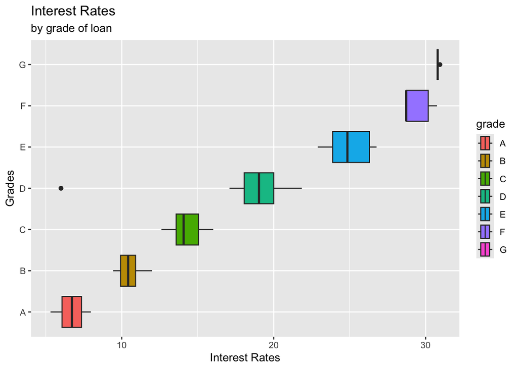

```r
ggplot(loans, aes(x = interest_rate,
                  y = grade, fill=grade)) +
  geom_boxplot() +
  labs(
    x = "Interest Rates",
    y = "Grades",
    title = "Interest Rates",
    subtitle = "by grade of loan"
  )
```

#### Using the loans dataframe and the idea that you can filter within the ggplot function, create a hexplot of `loan_amount` vs. `interest_rate` for `grade` (Hint: use the `fill` argument) values A thru F (exclude grade G). Please provide appropriate title(s) and labels.

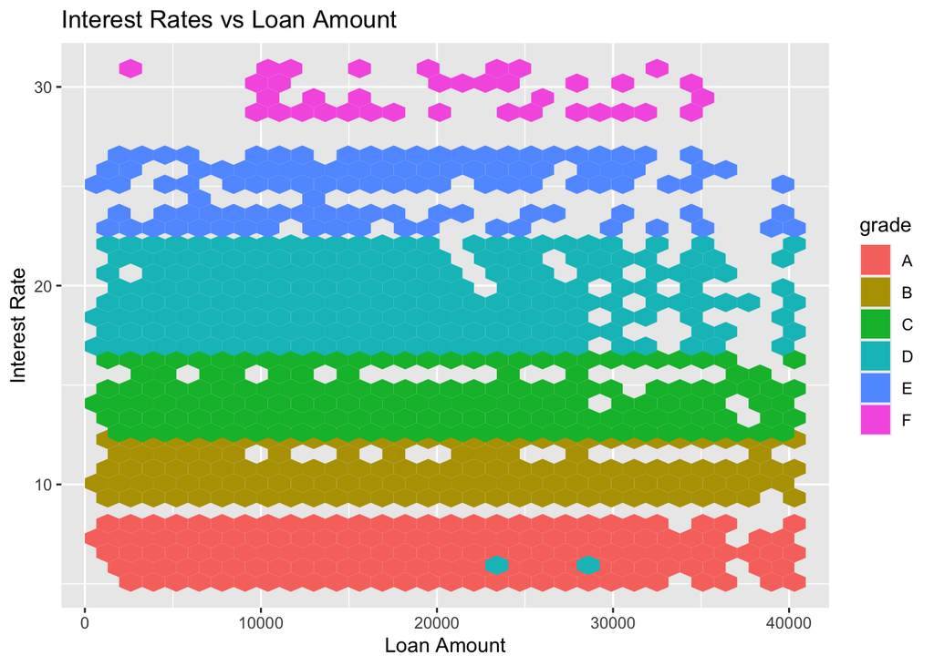

```r
ggplot(loans %>% filter(grade != "G"), aes(x=loan_amount, y=interest_rate, fill=grade)) +
  geom_hex() +
  labs(title = "Interest Rates vs Loan Amount",
       x="Loan Amount",
       y="Interest Rate")
```

#### Using the `loans` dataframe find the min, med, max, IQR, and num. of observations for `interest_rate` by `grade`. Label your statistics appropriately.

```r
loans %>%
  group_by(grade) %>%
  summarise(
    min_interest = min(interest_rate, na.rm = TRUE),
    med_interest = median(interest_rate, na.rm = TRUE),
    max_interest = max(interest_rate, na.rm = TRUE),
    IQR_interest = IQR(interest_rate, na.rm = TRUE),
    observations = n()
  )
```

```
## # A tibble: 7 × 6
##   grade min_interest med_interest max_interest IQR_interest observations
##   <fct>        <dbl>        <dbl>        <dbl>        <dbl>        <int>
## 1 A             5.31         6.72         7.97         1.28         2459
## 2 B             9.43        10.4         12.0          0.99         3037
## 3 C            12.6         14.1         16.0          1.47         2653
## 4 D             6           19.0         21.8          1.94         1446
## 5 E            22.9         24.8         26.8          2.42          335
## 6 F            28.7         28.7         30.8          1.45           58
## 7 G            30.8         30.8         30.9          0              12
```

#### Using the `loans` dataframe, create a segmented bar chart of `state` segmented by `homeownership`. The bars should be horizontal (not vertical) and the length of the bars should be the count for each state. The graph should have appropriate titles, and labels.

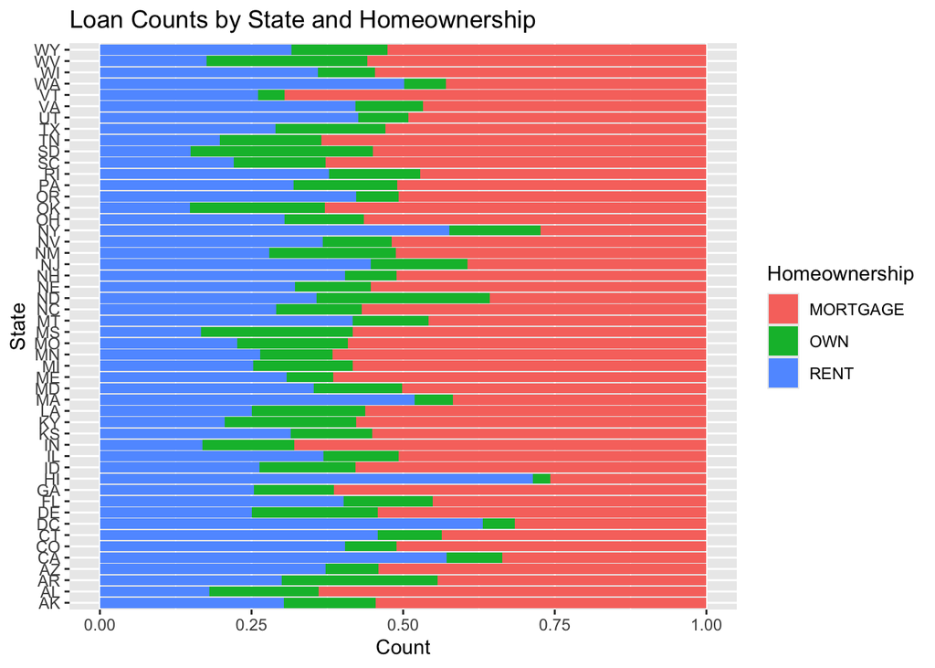

```r
ggplot(loans, aes( y = state, fill = homeownership)) +
  geom_bar(position = "fill") +
  labs(
    title = "Loan Counts by State and Homeownership",
    x = "Count",
    y = "State",
    fill = "Homeownership"
  )
```

#### Using the `loans` dataframe, create a frequency table of `grade`.

```r
loans %>% group_by(grade) %>% summarise(n = n())
```

```
## # A tibble: 7 × 2
##   grade     n
##   <fct> <int>
## 1 A      2459
## 2 B      3037
## 3 C      2653
## 4 D      1446
## 5 E       335
## 6 F        58
## 7 G        12
```